# act_report

## Act report

This project analyzes the WeRateDogs dataset, a page from tweeter. WeRateDogs is a Twitter account that rates people’s dogs with a humorous comment about the dog. The account was started in 2015 by a college student Matt Nelson. This account has attracted 8.8 million+ followers ever since.

Three datasets were used for this data analysis project (tweeter-archive-enhanced.csv, image-predictions.tsv and tweet-json.txt), and each were gathered in different ways given their different sources. Here, I will be sharing my insights using data visualizations. For this project, I answered 3 questions about the datasets used for this project. These questions are:

1. Q1: On average, which dog stage is most liked?
2. Q2: Which dog is most liked?
3. Q3: What is the relationship between retweet_count and favorite_count? These questions may not be very deep, but they reveal some things about the dataset.

**Research question 1** was answered using the lines of codes in the image attached below.

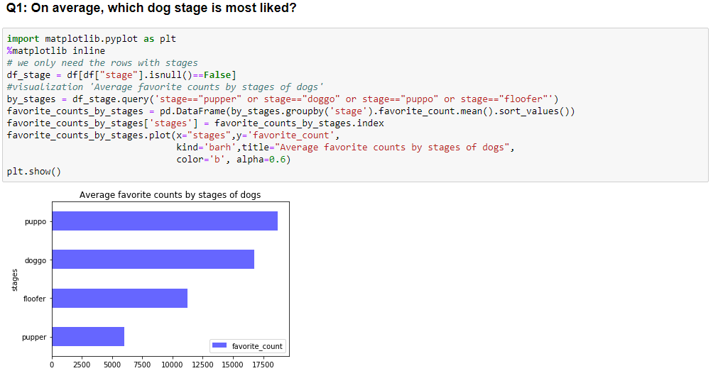

From the above attachment, it is clear that, on average, **puppo** is the most liked dog stage while **pupper** is the least liked dog stage in this list.

**Research question 2** was answered using the lines of codes in the image attached below.

[figure not shown]

**Research question 3** was answered using the lines of codes in the image attached below.

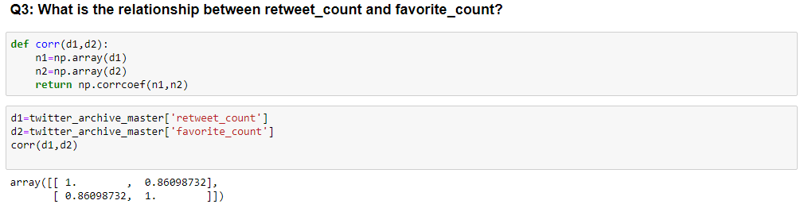

This result reveals that there is a **strong positive relationship between** *retweet_count* and *favorite_count* as informed by the correlation coefficient value of **0.8610** to 4 decimal places. I went further to visualize this relationship by plotting a scatter plot. This scatter plot is seen below.

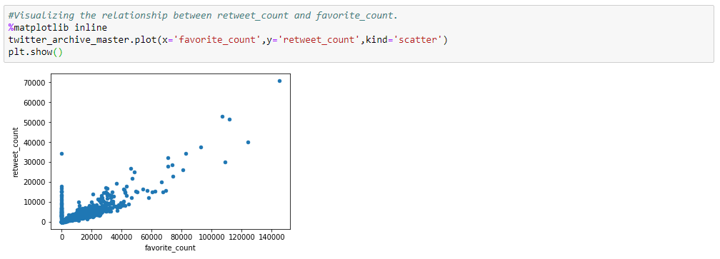

This brings us to the end of my data visualization report. I hope you enjoyed the session. For more, reach out to me via email: ibezimchisom007@gmail.com